# ‘White Wine Quality’ Data Analysis using R by Ng Fang Kiang

White Wine Quality: Click [Here](https://s3.amazonaws.com/udacity-hosted-downloads/ud651/wineQualityWhites.csv) to download. Sources: Created by: Paulo Cortez (Univ. Minho), Antonio Cerdeira, Fernando Almeida, Telmo Matos and Jose Reis (CVRVV) @ 2009

This dataset contains 4,898 rows of white wines records data and 11 columns of variables on quantifying the chemical properties of each wine. The last columns of this dataset have recorded the output of this dataset which is the quality of the wine that rated by at least 3 wine experts. The ratings are rated from the lowest of 0 to 10 that represented “VERY POOR” to “VERY EXCELLENT”!

## Description of attributes:

### Input variables (based on physicochemical tests):

1. **fixed.acidity** (tartaric acid - g / dm^3): most acids involved with wine or fixed or nonvolatile (do not evaporate readily)
2. **volatile.acidity** (acetic acid - g / dm^3): volatile acidity: the amount of acetic acid in wine, which at too high of levels can lead to an unpleasant, vinegar taste
3. **citric.acid** (g / dm^3): found in small quantities, citric acid can add ‘freshness’ and flavor to wines
4. **residual.sugar** (g / dm^3): the amount of sugar remaining after fermentation stops, it’s rare to find wines with less than 1 gram/liter and wines with greater than 45 grams/liter are considered sweet
5. **chlorides** (sodium chloride - g / dm^3): the amount of salt in the wine
6. **free.sulfur.dioxide** (mg / dm^3): the free form of SO2 exists in equilibrium between molecular SO2 (as a dissolved gas) and bisulfite ion; it prevents microbial growth and the oxidation of wine
7. **total.sulfur.dioxide** (mg / dm^3): amount of free and bound forms of S02; in low concentrations, SO2 is mostly undetectable in wine, but at free SO2 concentrations over 50 ppm, SO2 becomes evident in the nose and taste of wine
8. **density** (g / cm^3): the density of water is close to that of water depending on the percent alcohol and sugar content
9. **pH**: describes how acidic or basic a wine is on a scale from 0 (very acidic) to 14 (very basic); most wines are between 3-4 on the pH scale
10. **sulphates** (potassium sulphate - g / dm3): a wine additive which can contribute to sulfur dioxide gas (S02) levels, wich acts as an antimicrobial and antioxidant
11. **alcohol** (% by volume): the percent alcohol content of the wine

### Output variable (based on sensory data):

1. **quality** (score between 0 to 10)

## Utilization and Installation of Libraries/Packages

# Descriptive Statistics on different variables

```
## [1] "C:/Users/Jorcus/Documents/GitHub/DAND-Explore-and-Summarize-Data"
```

```
##  [1] "fixed.acidity"        "volatile.acidity"     "citric.acid"
##  [4] "residual.sugar"       "chlorides"            "free.sulfur.dioxide"
##  [7] "total.sulfur.dioxide" "density"              "pH"
## [10] "sulphates"            "alcohol"              "quality"
```

```
## [1] 4898   12
```

```
## 'data.frame':    4898 obs. of  12 variables:
##  $ fixed.acidity       : num  7 6.3 8.1 7.2 7.2 8.1 6.2 7 6.3 8.1 ...
##  $ volatile.acidity    : num  0.27 0.3 0.28 0.23 0.23 0.28 0.32 0.27 0.3 0.22 ...
##  $ citric.acid         : num  0.36 0.34 0.4 0.32 0.32 0.4 0.16 0.36 0.34 0.43 ...
##  $ residual.sugar      : num  20.7 1.6 6.9 8.5 8.5 6.9 7 20.7 1.6 1.5 ...
##  $ chlorides           : num  0.045 0.049 0.05 0.058 0.058 0.05 0.045 0.045 0.049 0.044 ...
##  $ free.sulfur.dioxide : num  45 14 30 47 47 30 30 45 14 28 ...
##  $ total.sulfur.dioxide: num  170 132 97 186 186 97 136 170 132 129 ...
##  $ density             : num  1.001 0.994 0.995 0.996 0.996 ...
##  $ pH                  : num  3 3.3 3.26 3.19 3.19 3.26 3.18 3 3.3 3.22 ...
##  $ sulphates           : num  0.45 0.49 0.44 0.4 0.4 0.44 0.47 0.45 0.49 0.45 ...
##  $ alcohol             : num  8.8 9.5 10.1 9.9 9.9 10.1 9.6 8.8 9.5 11 ...
##  $ quality             : int  6 6 6 6 6 6 6 6 6 6 ...
```

```
##  fixed.acidity    volatile.acidity  citric.acid     residual.sugar
##  Min.   : 3.800   Min.   :0.0800   Min.   :0.0000   Min.   : 0.600
##  1st Qu.: 6.300   1st Qu.:0.2100   1st Qu.:0.2700   1st Qu.: 1.700
##  Median : 6.800   Median :0.2600   Median :0.3200   Median : 5.200
##  Mean   : 6.855   Mean   :0.2782   Mean   :0.3342   Mean   : 6.391
##  3rd Qu.: 7.300   3rd Qu.:0.3200   3rd Qu.:0.3900   3rd Qu.: 9.900
##  Max.   :14.200   Max.   :1.1000   Max.   :1.6600   Max.   :65.800
##    chlorides       free.sulfur.dioxide total.sulfur.dioxide
##  Min.   :0.00900   Min.   :  2.00      Min.   :  9.0
##  1st Qu.:0.03600   1st Qu.: 23.00      1st Qu.:108.0
##  Median :0.04300   Median : 34.00      Median :134.0
##  Mean   :0.04577   Mean   : 35.31      Mean   :138.4
##  3rd Qu.:0.05000   3rd Qu.: 46.00      3rd Qu.:167.0
##  Max.   :0.34600   Max.   :289.00      Max.   :440.0
##     density             pH          sulphates         alcohol
##  Min.   :0.9871   Min.   :2.720   Min.   :0.2200   Min.   : 8.00
##  1st Qu.:0.9917   1st Qu.:3.090   1st Qu.:0.4100   1st Qu.: 9.50
##  Median :0.9937   Median :3.180   Median :0.4700   Median :10.40
##  Mean   :0.9940   Mean   :3.188   Mean   :0.4898   Mean   :10.51
##  3rd Qu.:0.9961   3rd Qu.:3.280   3rd Qu.:0.5500   3rd Qu.:11.40
##  Max.   :1.0390   Max.   :3.820   Max.   :1.0800   Max.   :14.20
##     quality
##  Min.   :3.000
##  1st Qu.:5.000
##  Median :6.000
##  Mean   :5.878
##  3rd Qu.:6.000
##  Max.   :9.000
```

[output not shown]

[output cut: 4884 more lines]

```
## wine
##
##  12  Variables      4898  Observations
## ---------------------------------------------------------------------------
## fixed.acidity
##        n  missing distinct     Info     Mean      Gmd      .05      .10
##     4898        0       68    0.998    6.855    0.925      5.6      5.9
##      .25      .50      .75      .90      .95
##      6.3      6.8      7.3      7.9      8.3
##
## lowest :  3.8  3.9  4.2  4.4  4.5, highest: 10.2 10.3 10.7 11.8 14.2
## ---------------------------------------------------------------------------
## volatile.acidity
##        n  missing distinct     Info     Mean      Gmd      .05      .10
##     4898        0      125    0.999   0.2782   0.1055     0.15     0.17
##      .25      .50      .75      .90      .95
##     0.21     0.26     0.32     0.40     0.46
##
## lowest : 0.080 0.085 0.090 0.100 0.105, highest: 0.910 0.930 0.965 1.005 1.100
## ---------------------------------------------------------------------------
## citric.acid
##        n  missing distinct     Info     Mean      Gmd      .05      .10
##     4898        0       87    0.999   0.3342   0.1258     0.17     0.22
##      .25      .50      .75      .90      .95
##     0.27     0.32     0.39     0.49     0.54
##
## lowest : 0.00 0.01 0.02 0.03 0.04, highest: 0.91 0.99 1.00 1.23 1.66
## ---------------------------------------------------------------------------
## residual.sugar
##        n  missing distinct     Info     Mean      Gmd      .05      .10
##     4898        0      310        1    6.391    5.548      1.1      1.2
##      .25      .50      .75      .90      .95
##      1.7      5.2      9.9     14.0     15.7
##
## lowest :  0.60  0.70  0.80  0.90  0.95, highest: 22.60 23.50 26.05 31.60 65.80
## ---------------------------------------------------------------------------
## chlorides
##        n  missing distinct     Info     Mean      Gmd      .05      .10
##     4898        0      160    0.999  0.04577  0.01708    0.027    0.030
##      .25      .50      .75      .90      .95
```

[output cut: 46 more lines]

```
##        n  missing distinct     Info     Mean      Gmd      .05      .10
##     4898        0      103    0.999    10.51    1.398      8.9      9.0
##      .25      .50      .75      .90      .95
##      9.5     10.4     11.4     12.4     12.7
##
## lowest :  8.00  8.40  8.50  8.60  8.70, highest: 13.80 13.90 14.00 14.05 14.20
## ---------------------------------------------------------------------------
## quality
##        n  missing distinct     Info     Mean      Gmd
##     4898        0        7    0.877    5.878   0.9377
##
## Value          3     4     5     6     7     8     9
## Frequency     20   163  1457  2198   880   175     5
## Proportion 0.004 0.033 0.297 0.449 0.180 0.036 0.001
## ---------------------------------------------------------------------------
```

# Univariate Plots Section

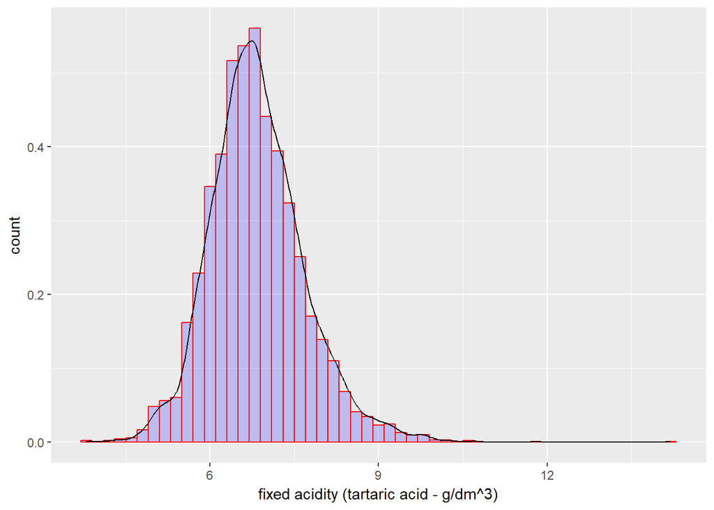

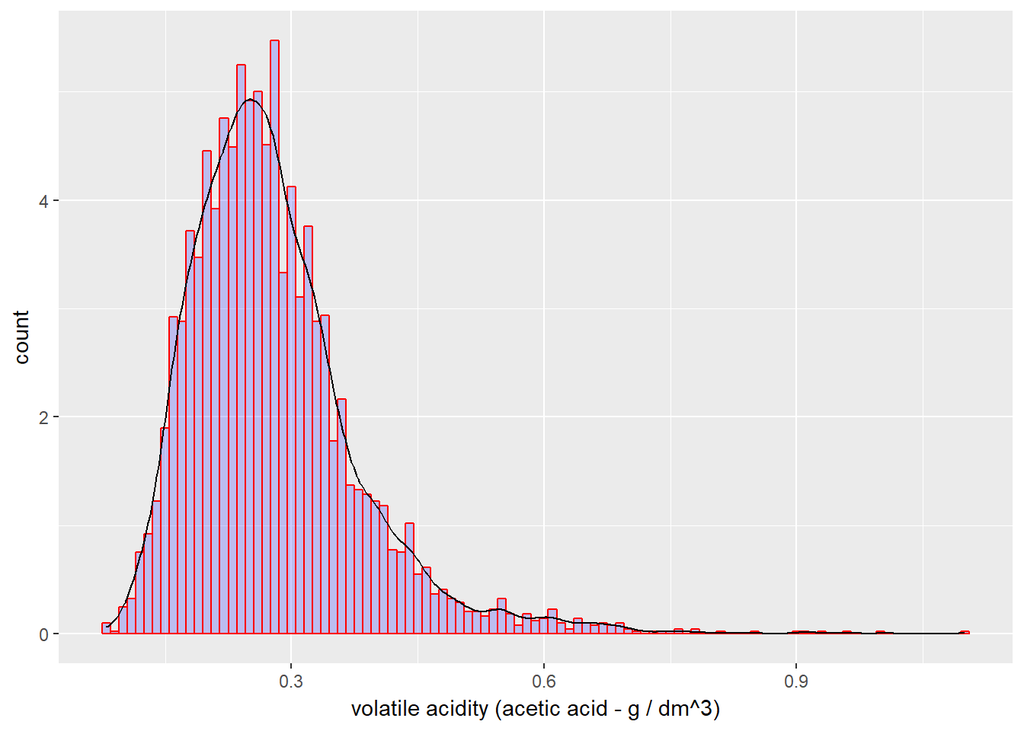

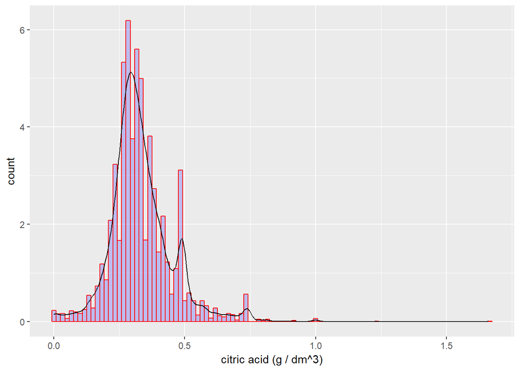

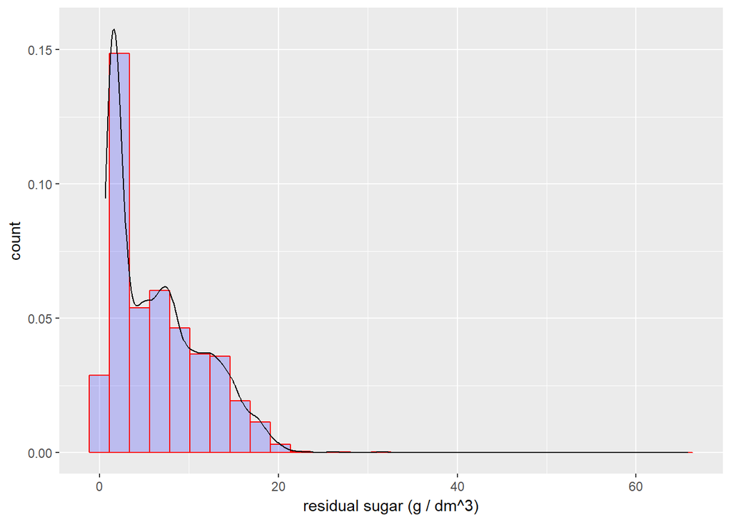

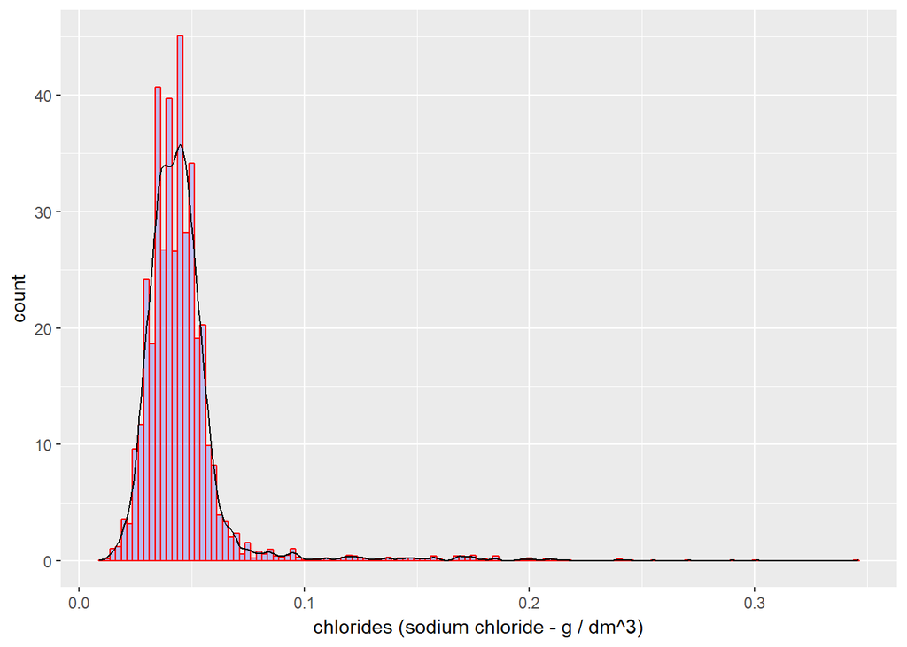

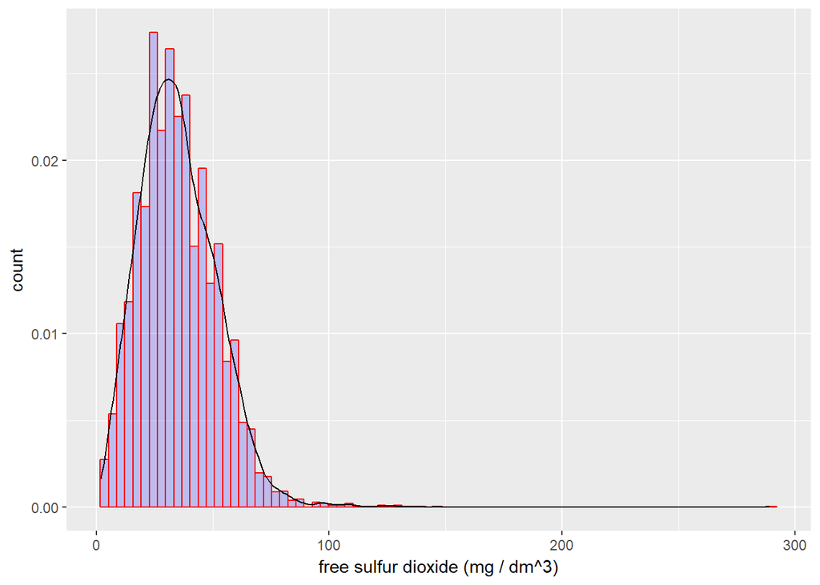

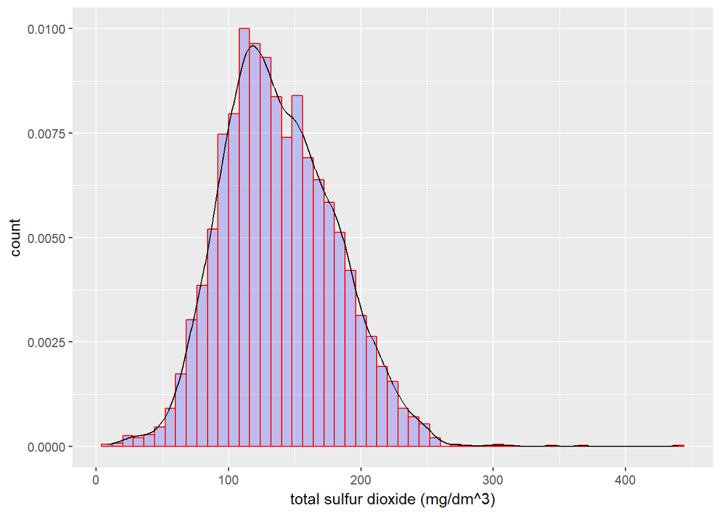

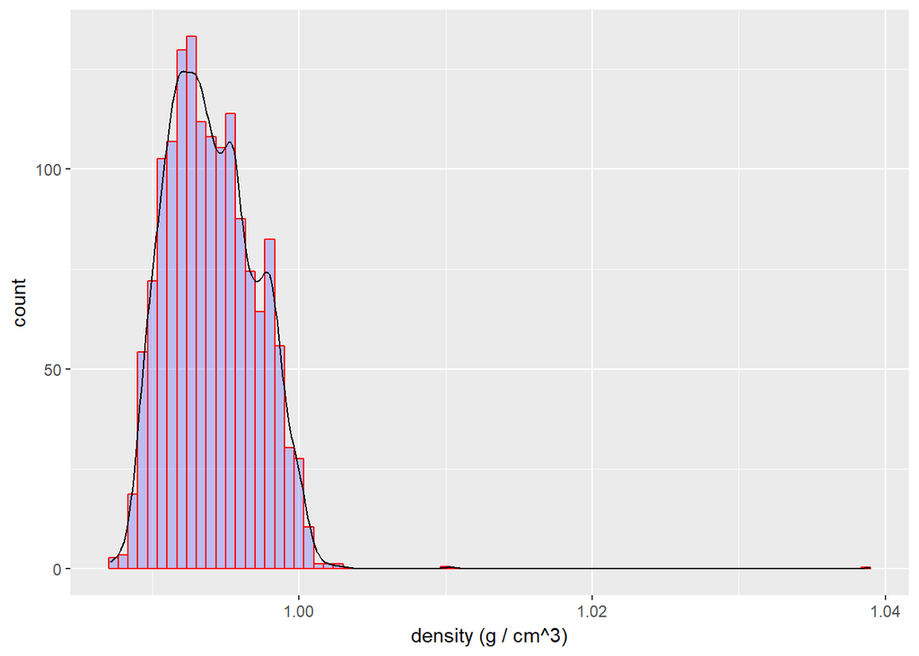

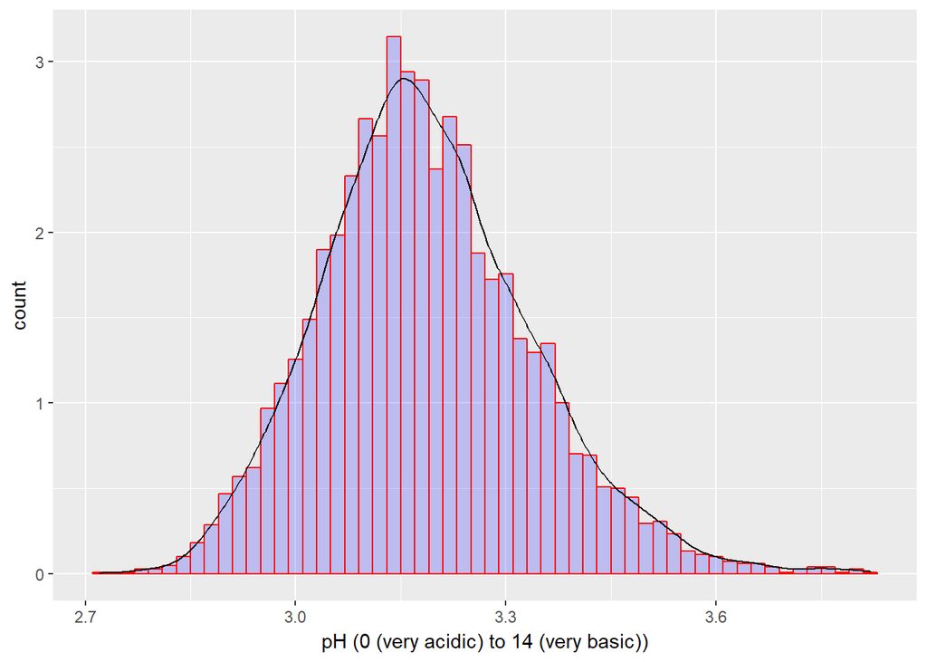

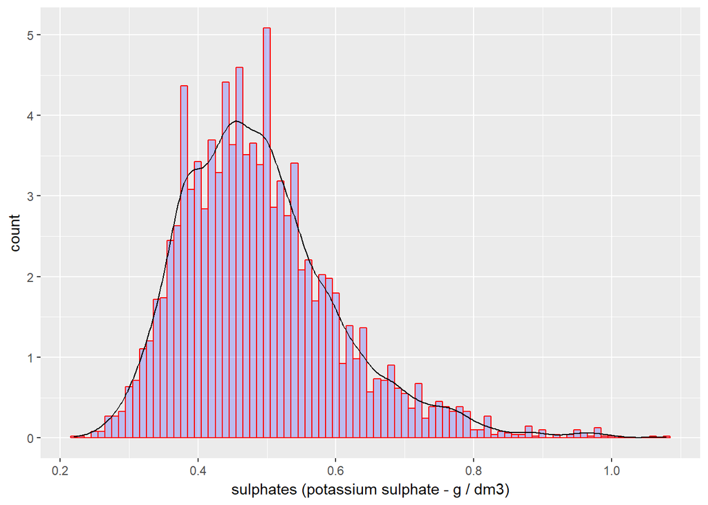

[figure not shown]

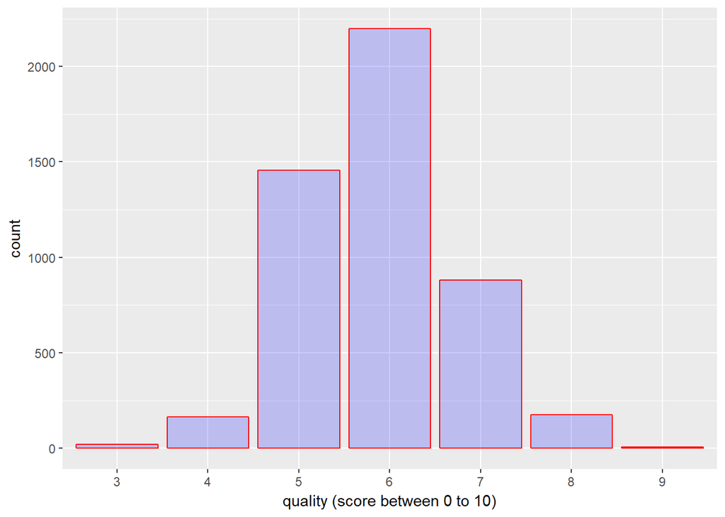

```
##
##    3    4    5    6    7    8    9
##   20  163 1457 2198  880  175    5
```

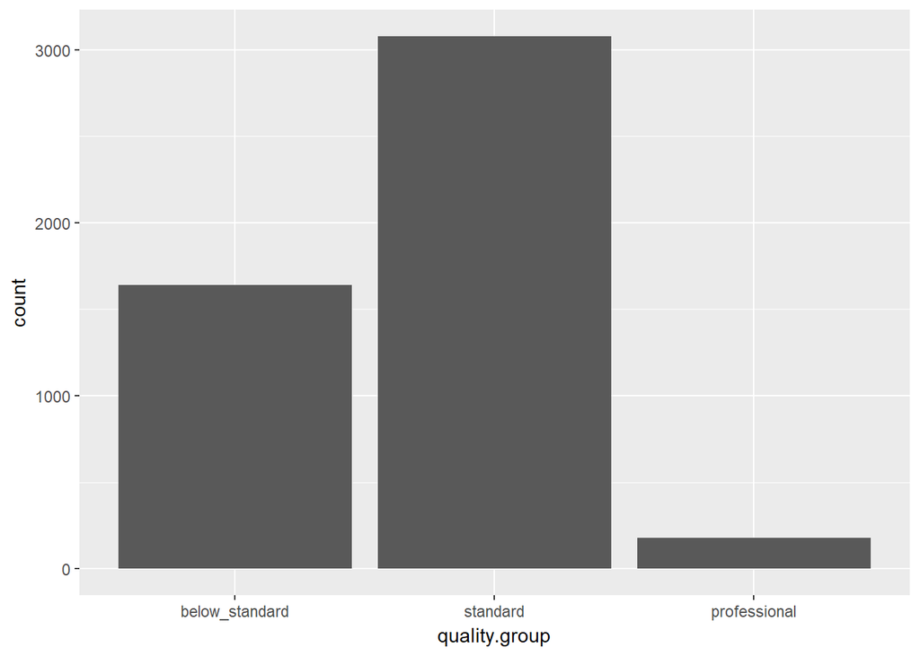

```
## below_standard       standard   professional
##           1640           3078            180
```

#### Understand the distribution

1. Most of the distribtion were skewed to right
2. The peak of volatile acidity is at the point around 0.29
3. The alcohol content is around 8-14
4. Quality has been categorize in three group, most of our white wine is in standard level.

# Univariate Analysis

### What is/are the main feature(s) of interest in your dataset?

The main interest in this dataset is to identifyt he chemical properties that influence the quality of the white wine. To estimate which chemical brings the best quality to white wines. I was wondering the percentage of alcohol does any impact to the quality of white wines.

### What other features in the dataset do you think will help support your investigation into your feature(s) of interest?

The output of 11 variable of chemical properties which influence the quality of white wine.

### Did you create any new variables from existing variables in the dataset?

Yes, we created a new group with cut() that categorize quality of white wine into three standard which is below_standard, standard, professional. below_standard => 0 ~ 5 standard => 6 ~ 7 professional => 8 ~ 10

### Of the features you investigated, were there any unusual distributions? Did you perform any operations on the data to tidy, adjust, or change the form of the data? If so, why did you do this?

According to the plot at above, most of the plot were skewed right. The outliers were disappear in the plot chart, I try to get a better quality of chart with modified the bin_width. It’s getting better, but not much help. However, I think most investigations should be done later on.

# Bivariate Plots Section

Simple Scatterplot to see the insight of the dataset

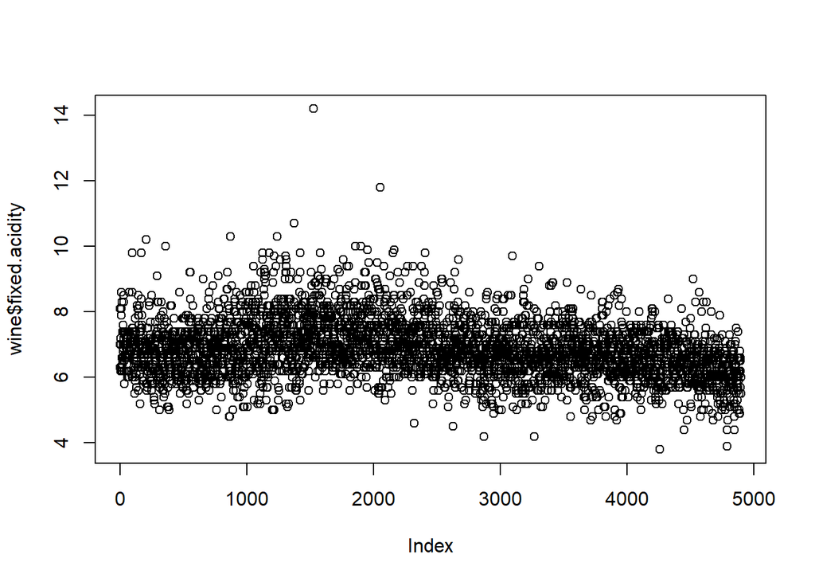

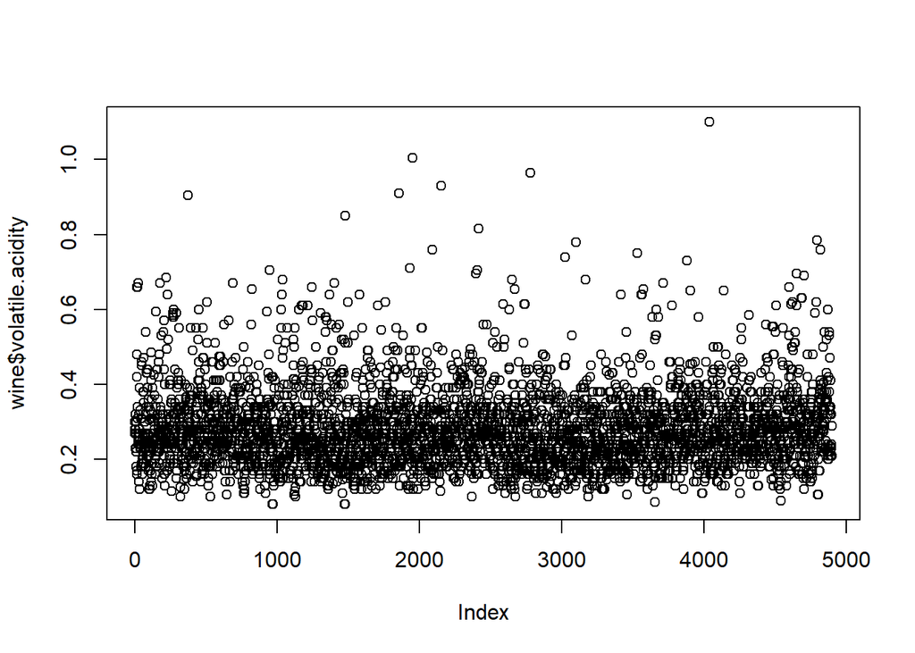

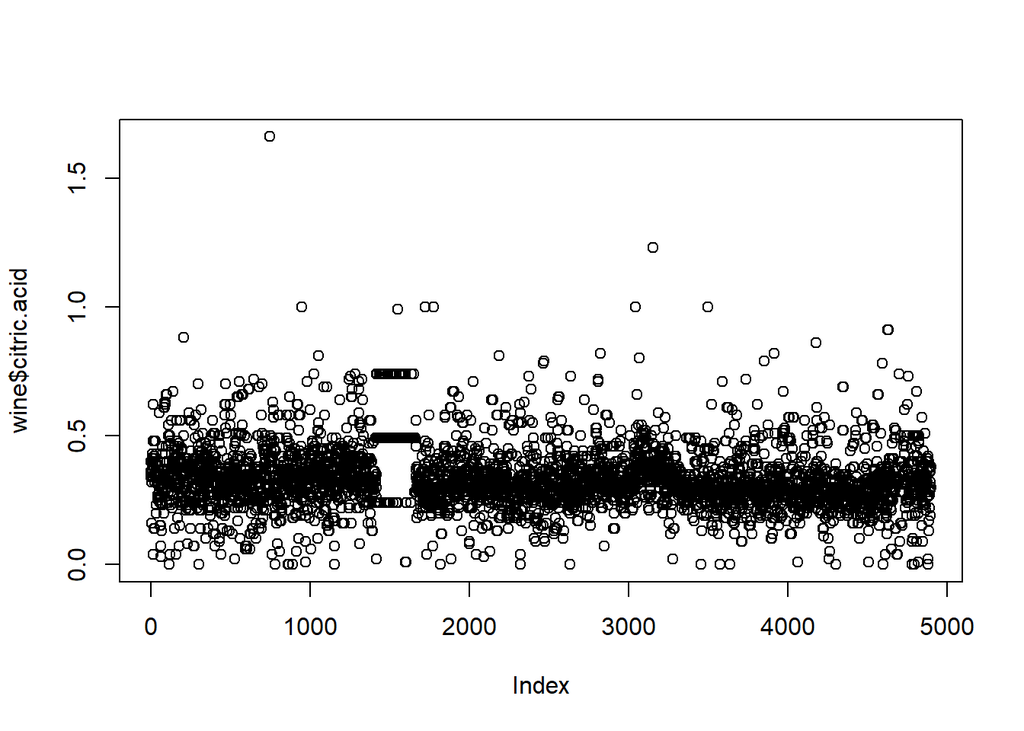

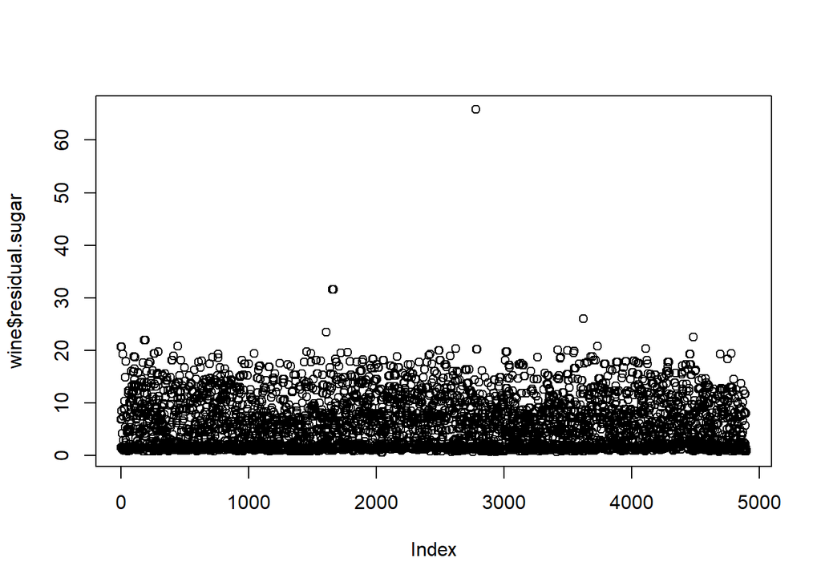

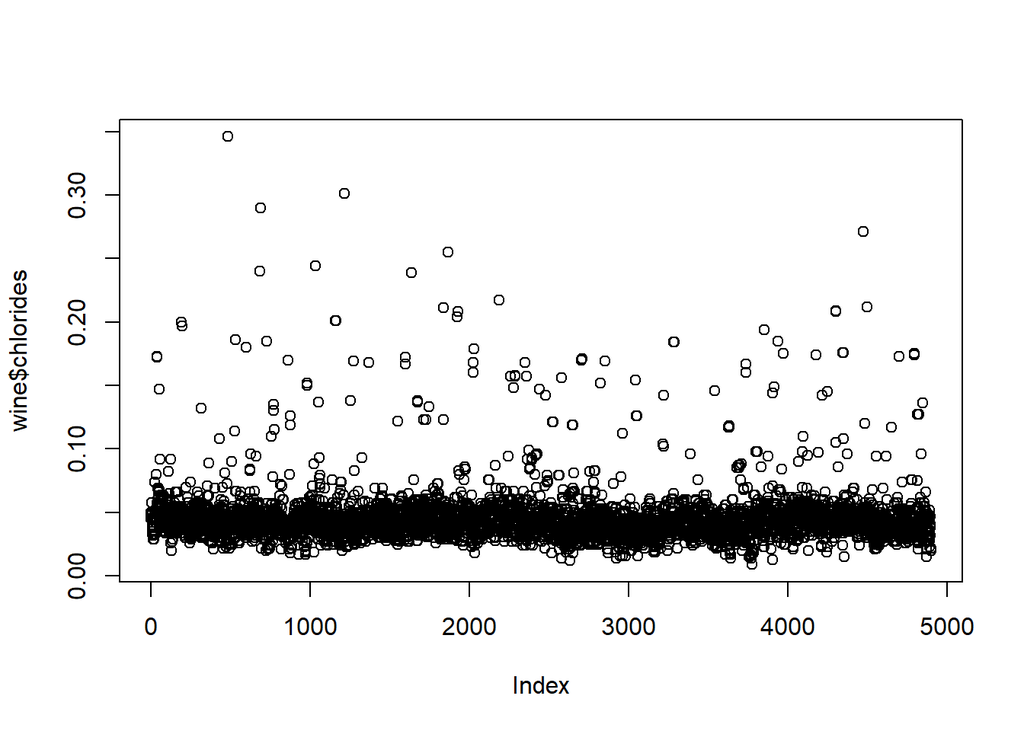

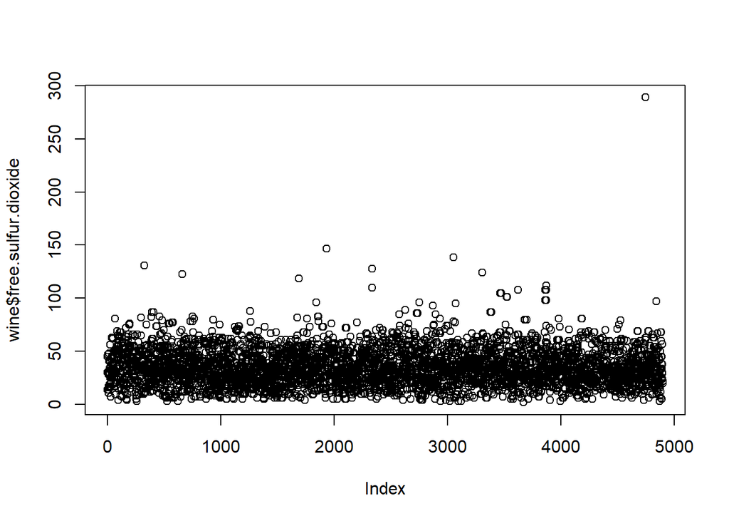

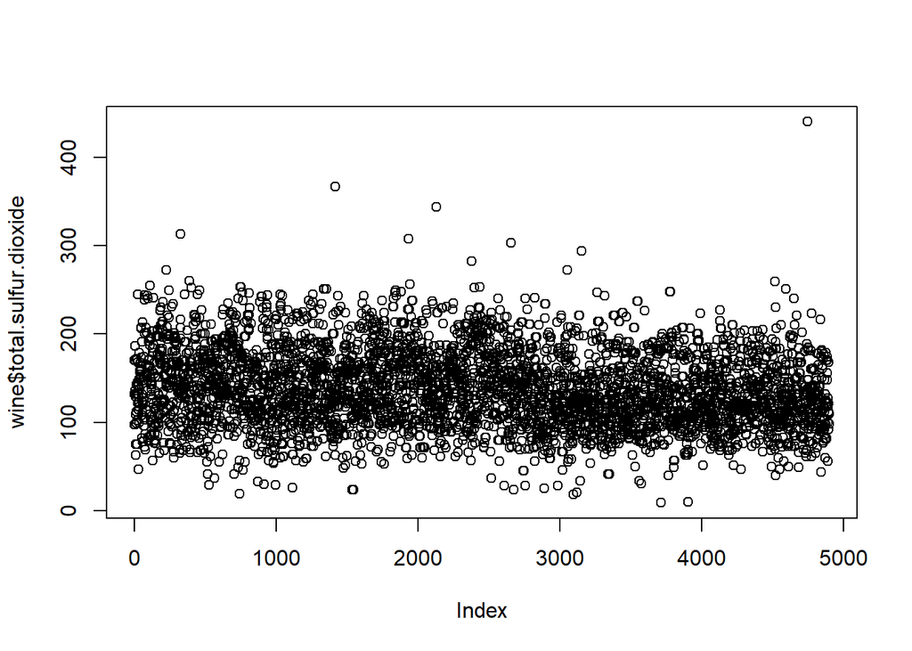

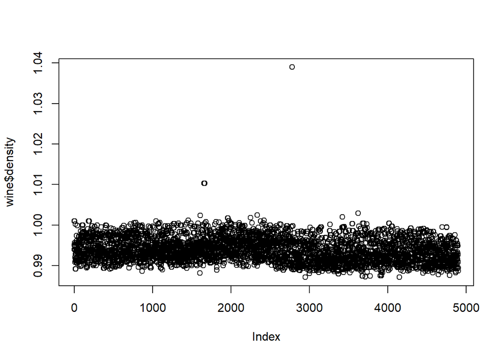

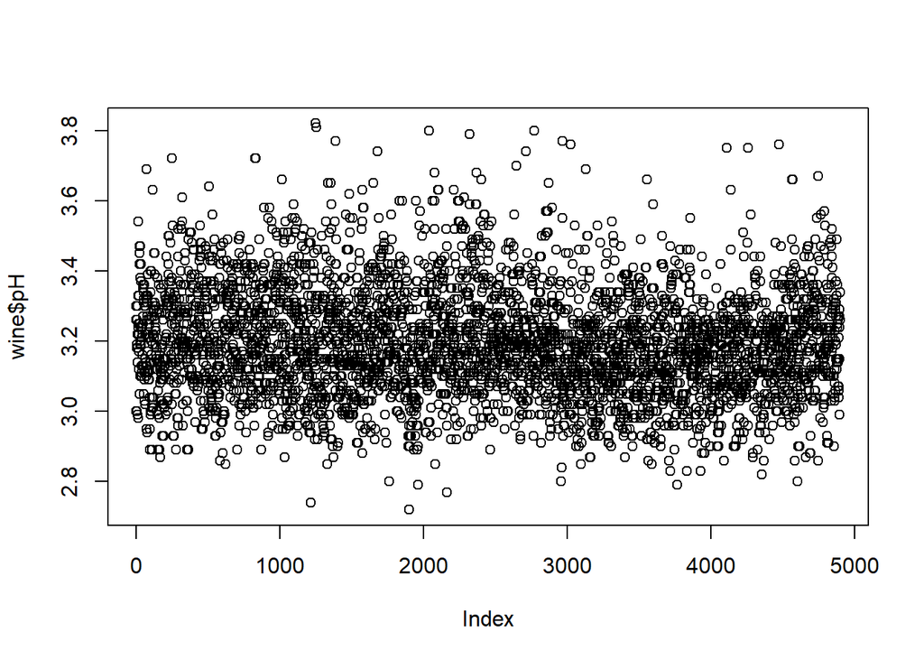

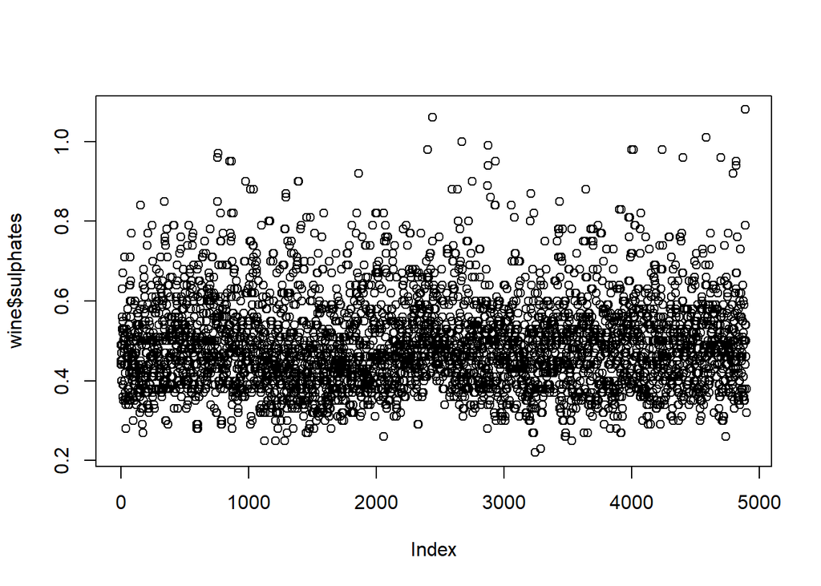

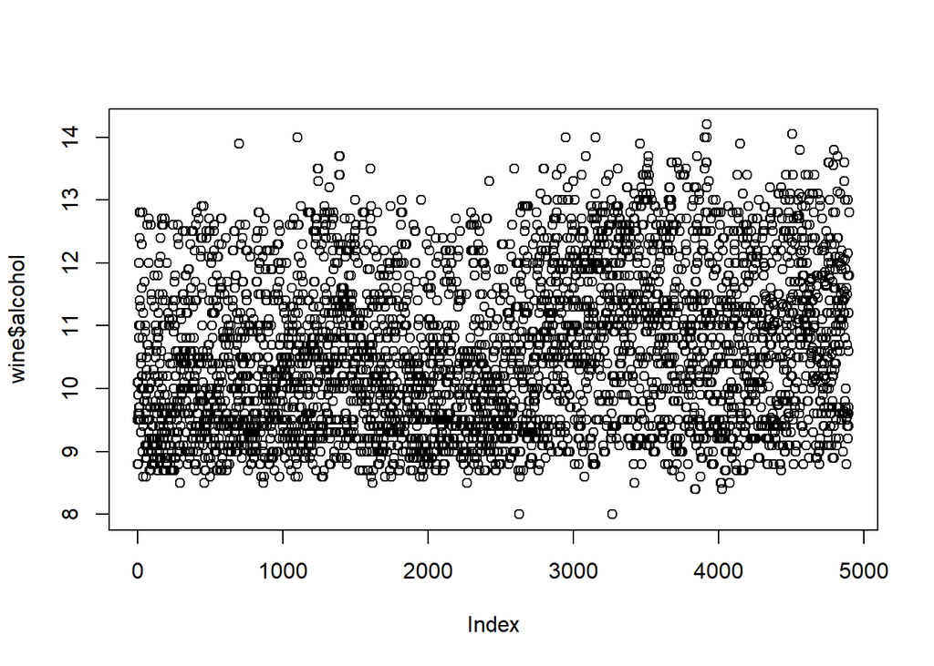

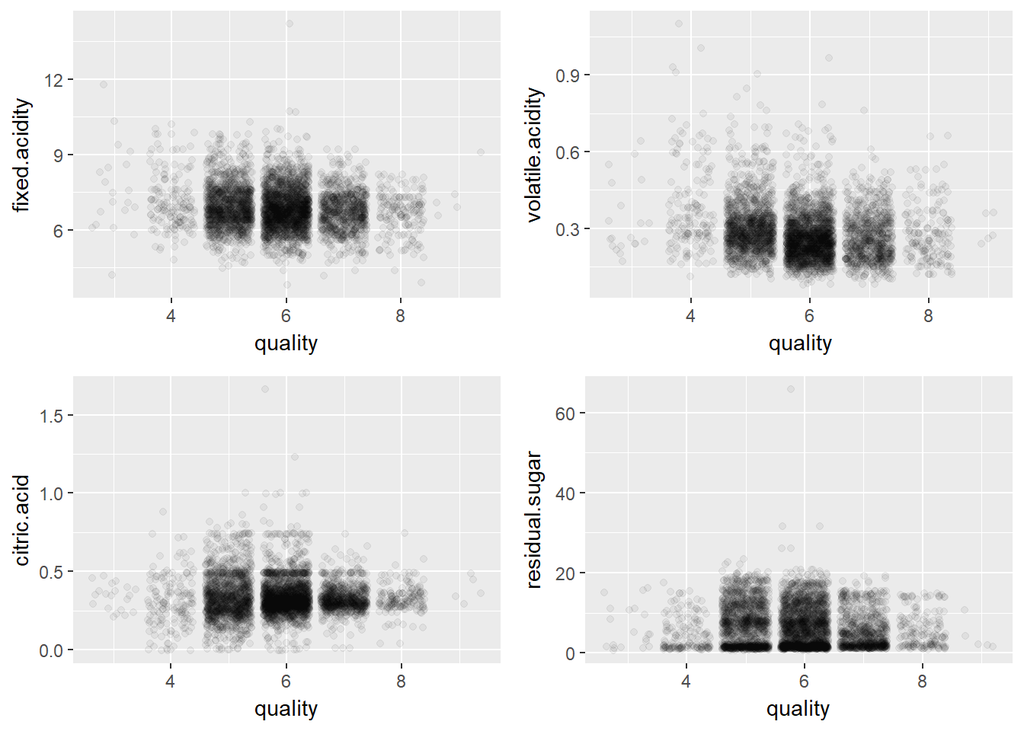

[4 more figures not shown]

According to the plot above, We probably can ignore the others correlation due to we found out the correlations.

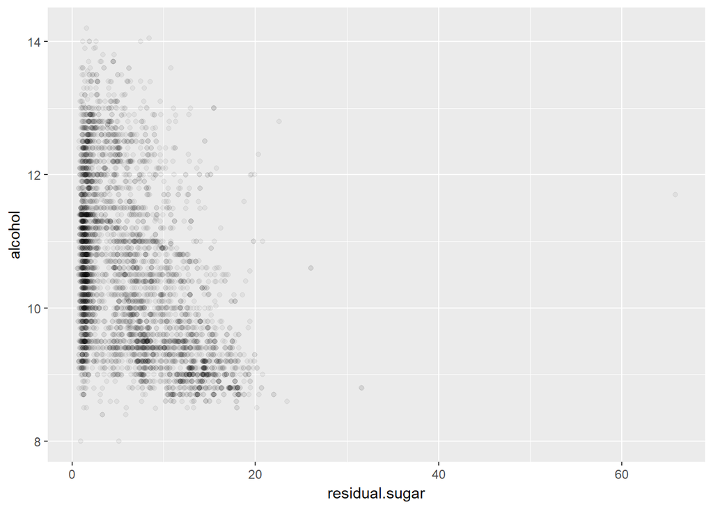

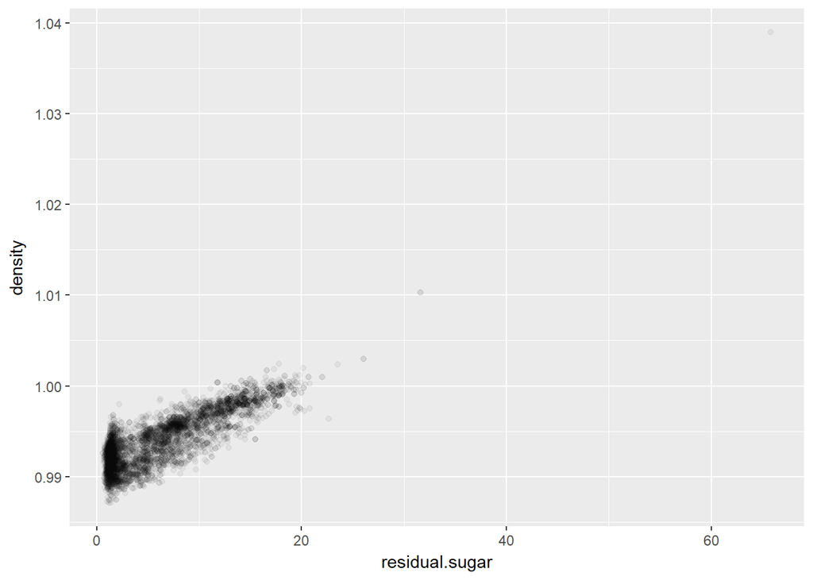

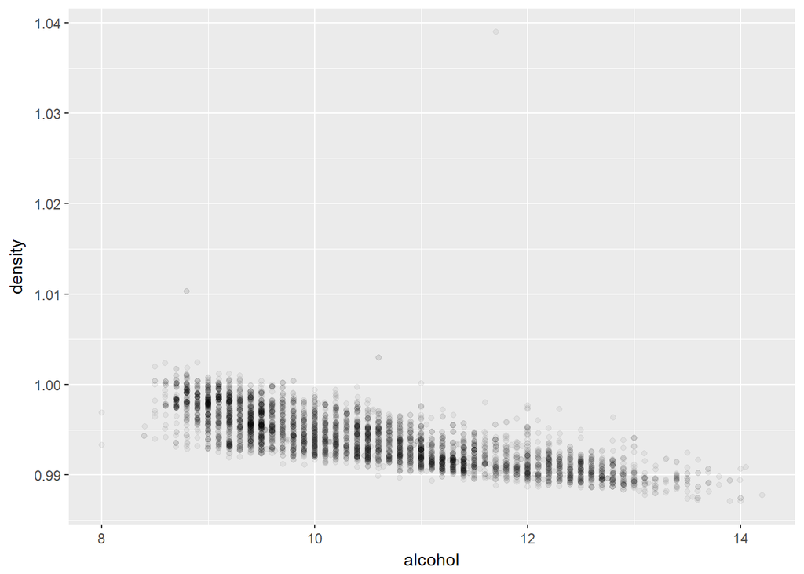

Here’s some insight of residual.sugar, alcohol and density. Seem like the graph have some outlier, which making the plot difficult to observe. I remove the outlier and name is as droped_outlier and visualize it.

Now, you can observe the graph easily!

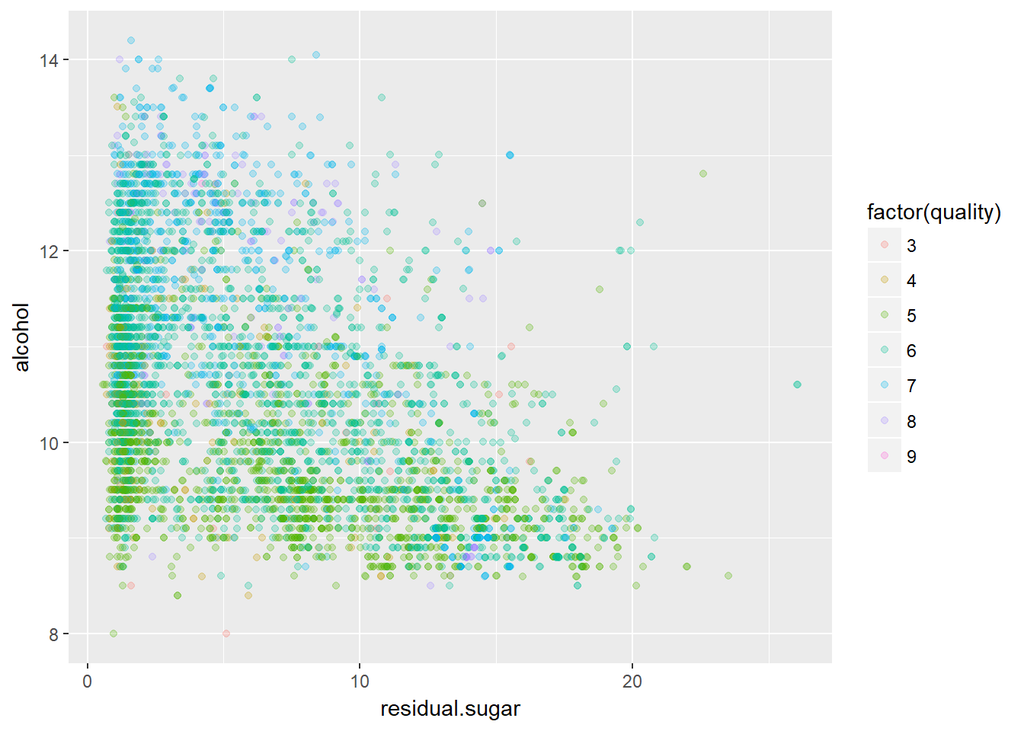

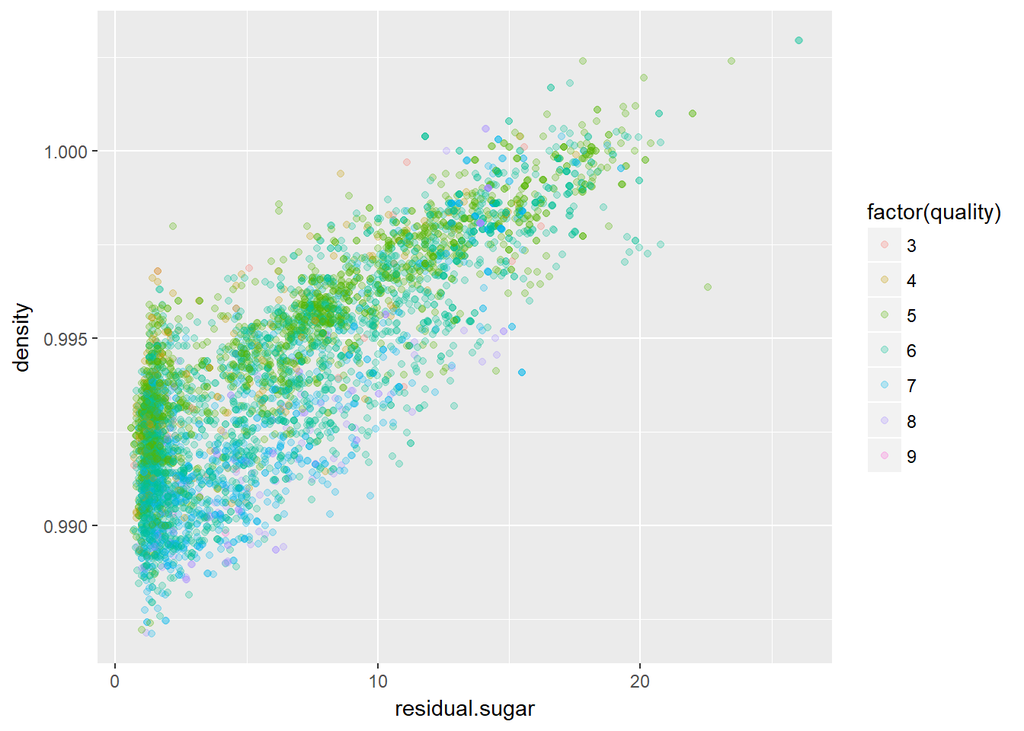

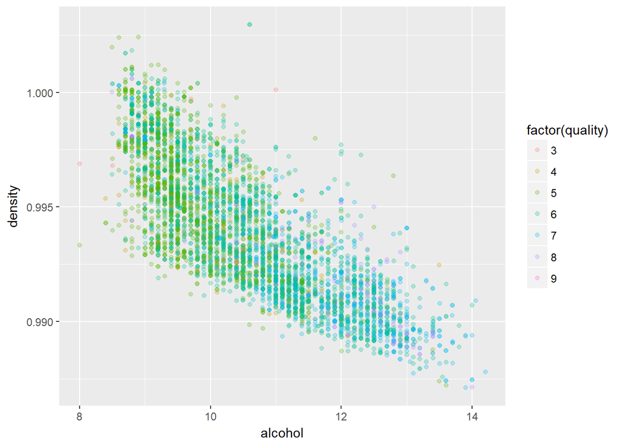